# Rozwiązania do zadań z lab 7

Kolejne zadania z tidymodels

Author

Dariusz Majerek

Published

April 13, 2026

```r
library(tidymodels)
library(workflowsets)
data(ames, package = "modeldata")
```

## Zadanie 1. Dwa modele regresji, jeden interfejs

Najpierw przygotowujemy próbkę danych i podział na zbiory.

```r
set.seed(2026)

diamonds_small <- diamonds %>%
  sample_n(6000) %>%
  mutate(log_price = log10(price))

diamonds_split <- initial_split(diamonds_small, prop = 0.8, strata = log_price)
diamonds_train <- training(diamonds_split)
diamonds_test <- testing(diamonds_split)
```

Definiujemy oba modele.

```r
lm_spec <- linear_reg() %>%
  set_engine("lm")

tree_spec <- decision_tree(cost_complexity = 0.001, tree_depth = 8, min_n = 10) %>%
  set_engine("rpart") %>%
  set_mode("regression")
```

Sprawdzamy tłumaczenie modeli.

```r
lm_spec %>% translate()
```

```
Linear Regression Model Specification (regression)

Computational engine: lm

Model fit template:
stats::lm(formula = missing_arg(), data = missing_arg(), weights = missing_arg())
```

```r
tree_spec %>% translate()
```

```
Decision Tree Model Specification (regression)

Main Arguments:
  cost_complexity = 0.001
  tree_depth = 8
  min_n = 10

Computational engine: rpart

Model fit template:
rpart::rpart(formula = missing_arg(), data = missing_arg(), weights = missing_arg(),
    cp = 0.001, maxdepth = 8, minsplit = min_rows(10, data))
```

Dopasowujemy oba modele z tą samą formułą.

```r
lm_fit <- lm_spec %>%
  fit(log_price ~ carat + depth + table + cut, data = diamonds_train)

tree_fit <- tree_spec %>%
  fit(log_price ~ carat + depth + table + cut, data = diamonds_train)
```

Porównujemy metryki na zbiorze testowym.

```r
lm_preds <- diamonds_test %>%
  select(log_price) %>%
  bind_cols(predict(lm_fit, new_data = diamonds_test))

tree_preds <- diamonds_test %>%
  select(log_price) %>%
  bind_cols(predict(tree_fit, new_data = diamonds_test))

bind_rows(
  metrics(lm_preds, truth = log_price, estimate = .pred) %>% mutate(model = "linear_reg"),
  metrics(tree_preds, truth = log_price, estimate = .pred) %>% mutate(model = "decision_tree")
) %>%
  select(model, .metric, .estimate)
```

```
# A tibble: 6 × 3
  model         .metric .estimate
  <chr>         <chr>       <dbl>
1 linear_reg    rmse       0.167
2 linear_reg    rsq        0.857
3 linear_reg    mae        0.131
4 decision_tree rmse       0.111
5 decision_tree rsq        0.937
6 decision_tree mae        0.0893
```

Dla lepszego modelu rysujemy wykres `predicted vs observed`.

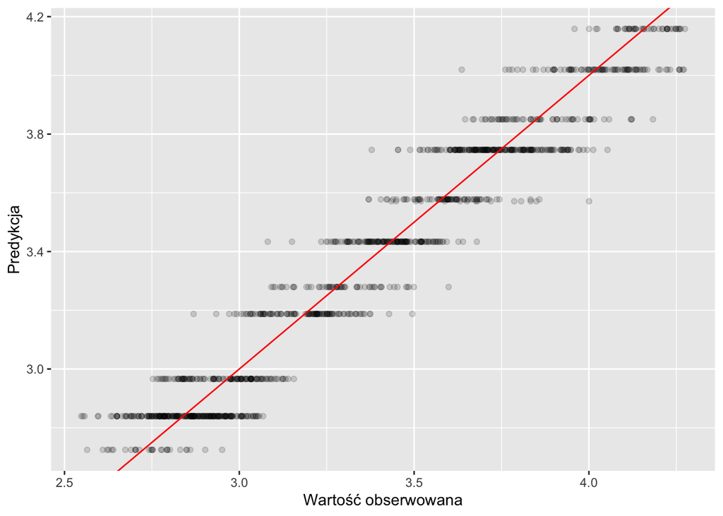

```r
tree_preds %>%
  ggplot(aes(x = log_price, y = .pred)) +
  geom_point(alpha = 0.15) +
  geom_abline(slope = 1, intercept = 0, color = "red") +
  labs(x = "Wartość obserwowana", y = "Predykcja")
```

Model drzewa daje tu wyraźnie lepsze dopasowanie niż prosty model liniowy.

## Zadanie 2. Wieloklasowa klasyfikacja w workflow

Przygotowujemy podział danych.

```r
set.seed(2026)

iris_split <- initial_split(iris, prop = 0.8, strata = Species)
iris_train <- training(iris_split)
iris_test <- testing(iris_split)
```

Tworzymy recepturę oraz model.

```r
iris_rec <- recipe(Species ~ ., data = iris_train) %>%
  step_normalize(all_numeric_predictors())

multi_spec <- multinom_reg() %>%
  set_engine("nnet") %>%
  set_mode("classification")
```

Łączymy wszystko w workflow i uczymy model.

```r
iris_wf <- workflow() %>%
  add_model(multi_spec) %>%
  add_recipe(iris_rec)

iris_fit <- fit(iris_wf, data = iris_train)
```

Predykcje klas i prawdopodobieństw:

```r
iris_preds <- iris_test %>%
  select(Species) %>%
  bind_cols(predict(iris_fit, new_data = iris_test)) %>%
  bind_cols(predict(iris_fit, new_data = iris_test, type = "prob"))

iris_preds %>%
  slice(1:6)
```

```
  Species .pred_class .pred_setosa .pred_versicolor .pred_virginica
1  setosa      setosa            1     2.957666e-21   6.035753e-237
2  setosa      setosa            1     6.221006e-18   3.253640e-222
3  setosa      setosa            1     9.363704e-19   2.414242e-223
4  setosa      setosa            1     6.231165e-21   1.669701e-240
5  setosa      setosa            1     2.909068e-16   2.122000e-223
6  setosa      setosa            1     1.399737e-20   1.350469e-222
```

Macierz pomyłek i accuracy:

```r
conf_mat(iris_preds, truth = Species, estimate = .pred_class)
```

```
            Truth
Prediction   setosa versicolor virginica
  setosa         10          0         0
  versicolor      0         10         2
  virginica       0          0         8
```

```r
accuracy(iris_preds, truth = Species, estimate = .pred_class)
```

```
# A tibble: 1 × 3
  .metric  .estimator .estimate
  <chr>    <chr>          <dbl>
1 accuracy multiclass     0.933
```

Najwięcej problemów sprawia zwykle rozróżnienie `versicolor` i `virginica`, podczas gdy `setosa` jest klasyfikowana bezbłędnie lub prawie bezbłędnie.

## Zadanie 3. Interakcje w `recipe()`

Przygotowujemy dane `ames`.

```r
set.seed(2026)

ames_inter <- ames %>%
  mutate(Sale_Price = log10(Sale_Price))

ames_split <- initial_split(ames_inter, prop = 0.8, strata = Sale_Price)
ames_train <- training(ames_split)
ames_test <- testing(ames_split)
```

Tworzymy dwa przepisy: prostszy oraz z interakcją.

```r
simple_rec <- recipe(
  Sale_Price ~ Neighborhood + Gr_Liv_Area + Year_Built + Bldg_Type,
  data = ames_train
) %>%
  step_log(Gr_Liv_Area, base = 10) %>%
  step_other(Neighborhood, threshold = 0.01) %>%
  step_dummy(all_nominal_predictors())

inter_rec <- recipe(
  Sale_Price ~ Neighborhood + Gr_Liv_Area + Year_Built + Bldg_Type,
  data = ames_train
) %>%
  step_log(Gr_Liv_Area, base = 10) %>%
  step_other(Neighborhood, threshold = 0.01) %>%
  step_dummy(all_nominal_predictors()) %>%
  step_interact(~ Gr_Liv_Area:starts_with("Bldg_Type_"))
```

Specyfikujemy model i budujemy workflow.

```r
ames_lm_spec <- linear_reg() %>%
  set_engine("lm")

simple_fit <- workflow() %>%
  add_model(ames_lm_spec) %>%
  add_recipe(simple_rec) %>%
  fit(data = ames_train)

inter_fit <- workflow() %>%
  add_model(ames_lm_spec) %>%
  add_recipe(inter_rec) %>%
  fit(data = ames_train)
```

Porównanie wyników na zbiorze testowym:

```r
simple_preds <- ames_test %>%
  select(Sale_Price) %>%
  bind_cols(predict(simple_fit, new_data = ames_test))

inter_preds <- ames_test %>%
  select(Sale_Price) %>%
  bind_cols(predict(inter_fit, new_data = ames_test))

bind_rows(
  metrics(simple_preds, truth = Sale_Price, estimate = .pred) %>% mutate(model = "bez_interakcji"),
  metrics(inter_preds, truth = Sale_Price, estimate = .pred) %>% mutate(model = "z_interakcja")
) %>%
  select(model, .metric, .estimate)
```

```
# A tibble: 6 × 3
  model          .metric .estimate
  <chr>          <chr>       <dbl>
1 bez_interakcji rmse       0.0748
2 bez_interakcji rsq        0.816
3 bez_interakcji mae        0.0549
4 z_interakcja   rmse       0.0750
5 z_interakcja   rsq        0.815
6 z_interakcja   mae        0.0555
```

Podejrzenie oszacowanej receptury dla modelu z interakcją:

```r
estimated_inter_rec <- inter_fit %>%
  extract_recipe(estimated = TRUE)

tidy(estimated_inter_rec)
```

```
# A tibble: 4 × 6
  number operation type     trained skip  id
   <int> <chr>     <chr>    <lgl>   <lgl> <chr>
1      1 step      log      TRUE    FALSE log_XJb3S
2      2 step      other    TRUE    FALSE other_oz3B3
3      3 step      dummy    TRUE    FALSE dummy_TruxA
4      4 step      interact TRUE    FALSE interact_cFMqY
```

## Zadanie 4. `workflow_set()` dla różnych modeli i preprocessingu

Przygotowujemy dwa warianty preprocessingu oraz dwa modele.

```r
engineered_rec <- recipe(
  Sale_Price ~ Neighborhood + Gr_Liv_Area + Year_Built + Bldg_Type,
  data = ames_train
) %>%
  step_log(Gr_Liv_Area, base = 10) %>%
  step_other(Neighborhood, threshold = 0.01) %>%
  step_dummy(all_nominal_predictors())

preproc_list <- list(
  coords = Sale_Price ~ Longitude + Latitude,
  engineered = engineered_rec
)

model_list <- list(
  lm = linear_reg() %>% set_engine("lm"),
  tree = decision_tree(cost_complexity = 0.001, tree_depth = 8, min_n = 10) %>%
    set_engine("rpart") %>%
    set_mode("regression")
)
```

Tworzymy i dopasowujemy `workflow_set()`.

```r
wf_set <- workflow_set(
  preproc = preproc_list,
  models = model_list
)

wf_set <- wf_set %>%
  mutate(
    fit = map(info, ~ fit(.x$workflow[[1]], data = ames_train)),
    preds = map(fit, ~ bind_cols(
      ames_test %>% select(Sale_Price),
      predict(.x, new_data = ames_test)
    )),
    metrics = map(preds, ~ metrics(.x, truth = Sale_Price, estimate = .pred))
  )
```

Porównujemy wyniki.

```r
wf_results <- wf_set %>%
  select(wflow_id, metrics) %>%
  unnest(metrics) %>%
  select(wflow_id, .metric, .estimate)

wf_results
```

```
# A tibble: 12 × 3
   wflow_id        .metric .estimate
   <chr>           <chr>       <dbl>
 1 coords_lm       rmse       0.157
 2 coords_lm       rsq        0.188
 3 coords_lm       mae        0.122
 4 coords_tree     rmse       0.0984
 5 coords_tree     rsq        0.686
 6 coords_tree     mae        0.0733
 7 engineered_lm   rmse       0.0748
 8 engineered_lm   rsq        0.816
 9 engineered_lm   mae        0.0549
10 engineered_tree rmse       0.0826
11 engineered_tree rsq        0.778
12 engineered_tree mae        0.0624
```

Ranking po `rmse`:

```r
wf_results %>%
  filter(.metric == "rmse") %>%
  arrange(.estimate)
```

```
# A tibble: 4 × 3
  wflow_id        .metric .estimate
  <chr>           <chr>       <dbl>
1 engineered_lm   rmse       0.0748
2 engineered_tree rmse       0.0826
3 coords_tree     rmse       0.0984
4 coords_lm       rmse       0.157
```

Najlepszy workflow wykorzystuje zwykle bogatszy preprocessing i model liniowy, czyli `engineered_lm`. W tym porównaniu daje on najniższy błąd i najwyższe `rsq`, więc jest najrozsądniejszym wyborem spośród czterech analizowanych wariantów.